# BMDx2 Manual

# Introduction

BMDx is an R Shiny graphical interface tool for the dose dependent analysis of transcriptomic data.

BMDx implements a multi-step pipeline that include the following steps: - Set mode - Load phenotype data - Load experimental data, e.g. normalized expression matrix and vst normalized expression matrix with blind=False for microarray and RNA-seq downstream analysis - Filtering - Benchmark dose analysis - Functional enrichment with the FunMappOne tool, e.g. KEGG pathways - Gene pairs analysis - AOP and KE enrichment - Download report

BMDx not only allows the user to compare the results between multiple time points, but also multiple experiments at once. Results along the way are visualised as several types of plots and the output can be downloaded as Excel files or figures in pdf format at multiple steps of the analysis.

The final results include the estimation of effective doses (BMD/BMDL/BMDU) for each dose-dependent gene. These estimates can be used for further analysis to help construct a biological interpretation of the exposure of interest.

# Set mode

BMDx is implemented to work in a dual mode: GLP (Good Laboratory Practice) and non-GLP mode. If GLP mode is selected by the user, all the steps of the analysis will be recorded in a log file. Furthermore, at every step of the analysis the user will be prompted to add information about the analysis. First, the user will be asked to give a description about the aims of the analysis. Next, for every step that the user perform, an explanation for performing the step and the selected values for the parameters will be requested.

# Format of data input

BMDx takes as an input a phenotype file and an expression matrix, both provided as an Excel spreadsheet (xlsx). If multiple experiments are included, both files must contain separate sheets for each experiment in corresponding orders. Specific instructions for the file structures are provided below. Sample data can be found [here](https://github.com/Greco-Lab/BMDx).

## Phenodata

The phenotype file is an Excel file containing separate sheets for each experiment. Each sheet contains information about the samples used in the specific experiment. In particular, BMDx requires the spreadsheets to have at least three columns that specify the following characteristics: 1) Unique sample IDs corresponding to the column names in the expression matrix, 2) condition (e.g., dose) and 3) the time points included in the experiment. Each sheet must have the columns (sample ID, condition, and time point) in the same positions.

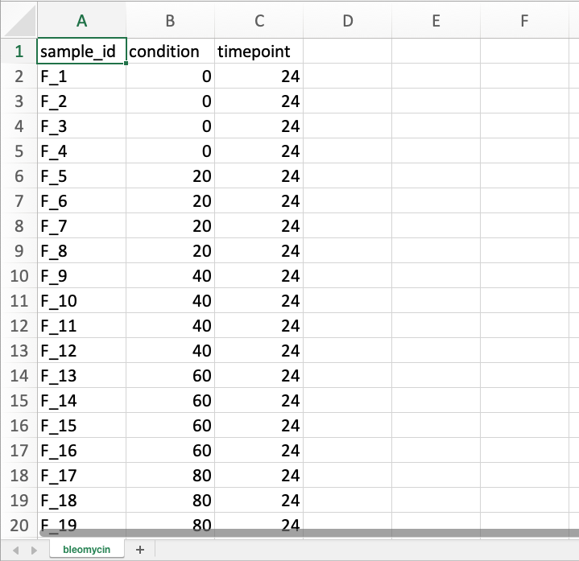

Sample pheno data

The required parameters are the following:

- **Path to pheno data file:** Browse and select the file from your local system
- **Sample ID variable:** Column name of the phenodata of the samples IDs
- **Dose variable:** Column name of the phenodata of the dose levels
- **Time point variable:** Column name of the phenodata of the time points
- **Optional variable:** Column names of the phenodata that can be used during the analysis to group the results

Once all options are set, load the phenotype data and proceed to the next step.

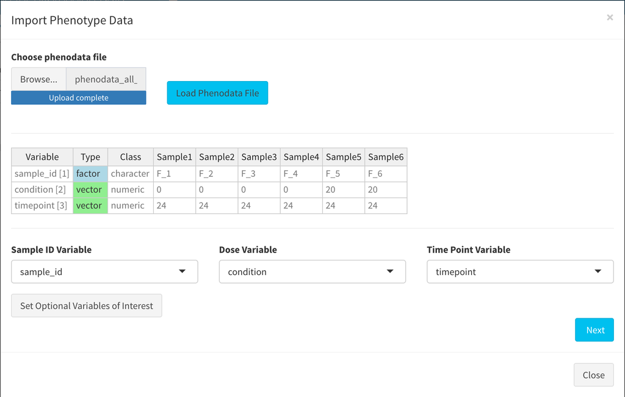

An overview of the metadata is presented in the “Metadata data” window.

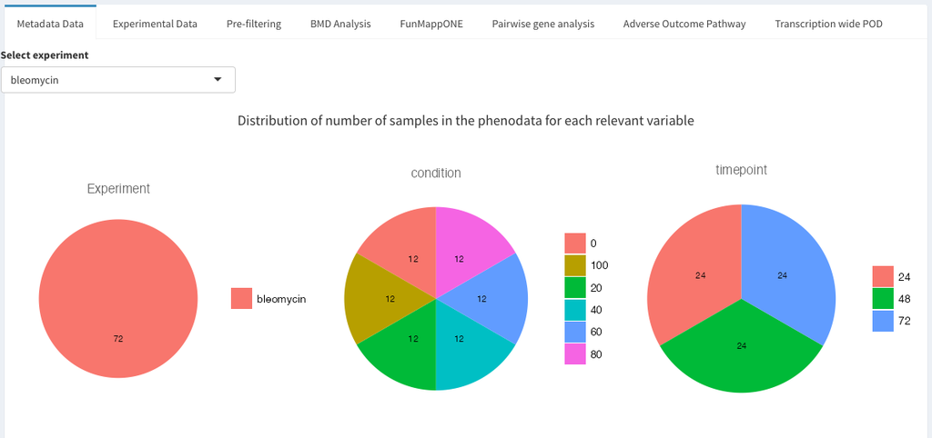

Overview metadata

## Expression data

The expression matrix is an Excel file with a separate sheet for each experiment. Each experiment involves a unique test system or materials being tested, such as different cell lines or treatments. Note that different doses or timepoints tested within the same system are not considered separate experiments. Sample columns are named with unique sample IDs that match the sample IDs provided in the phenotype file. Gene names must be provided in the first column of each spreadsheet, and each following column specifies the expression values for those genes in each individual sample. The order of the sheets must match the order of the sheets in the phenotype file.

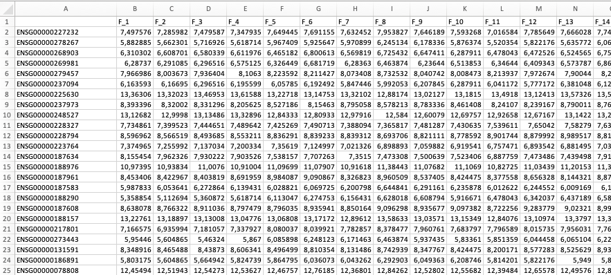

The required parameters are the following:

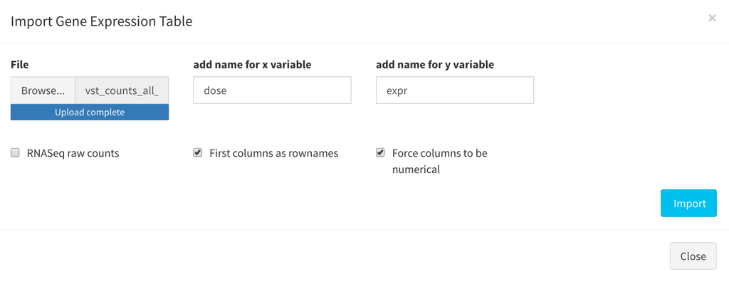

Load expression data parameters

Once all options are set, import the normalized expression matrix and proceed to the next step. An overview of the gene expression matrix is presented in the “Experimental data” window.

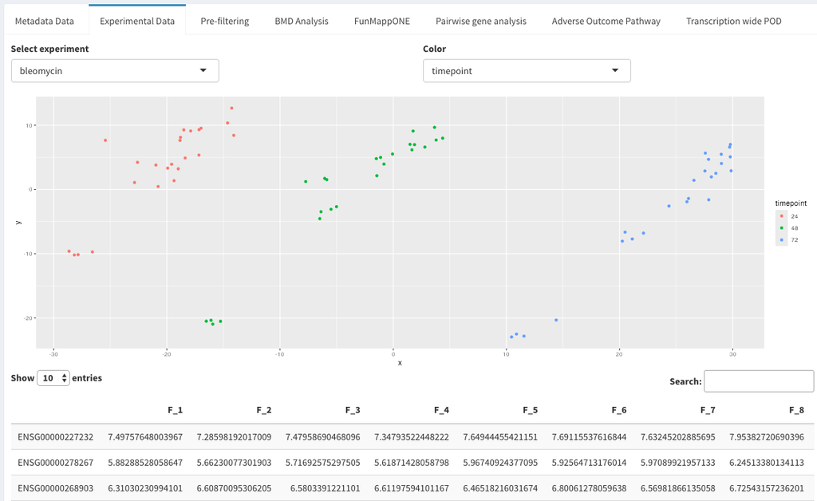

Overview expression data

# Filtering

The number of genes (or molecules) profiled by transcriptomic data is usually high. Thus, in order to reduce the time of the BMDx analysis and focus on relevant genes, different filtering criteria are available:

- **ANOVA:** ANOVA is used to test the null hypothesis that the mean responses (e.g. expression of the genes) at the different doses are the same. The alternative hypothesis is that the response is different in at least one of the doses. If the p-value is below a certain threshold (e.g. 0.05) then we reject the null hypothesis that each dose mean response is the same.
- **Mann-Kendall Trend test:** The Mann-Kendall Trend tests is performed under the null hypothesis that the data come from a population with independent realizations and are identically distributed. The alternative hypothesis is that the data follow a monotonic trend. If the p-value is below a certain threshold (e.g. 0.05) then the null hypothesis is reject and the response is considered to follow a monotonic trend.
- **Filter by fold-change:** The filter by fold-change is performed by performing a limma analysis between the treated samples (all the different doses) against the controls of each individual time-point. Details on the limma package can be found [here](https://bioconductor.org/packages/release/bioc/html/limma.html).
- **Trend filtering:** It allows for filtering genes that do not exhibit a linear trend. For each data point and the next, you compute the derivative and ensure they all have the same sign. This method is less stringent than monotonic filtering, as monotonic filtering requires a consistent increase or decrease between consecutive points.

The user can also decide to skip the filtering.

## ANOVA and Trend test parameters

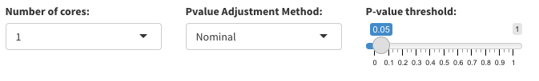

Anova and trend test parameters

## ANOVA and Trend test filtering Results

The results of the Anova and Trend test analysis will be displayed in a table with the following columns: - **Exp:** the name of the experiment - **Time:** the time point of the experiment - **Feature:** the name of the gene - **Pvalue:** the p-value obtained from the analysis - **adjPVal:** the adjusted p-values - **usedFilteringPVal:** the p-value used to filter the results. If the adjustment is performed, usedFilteringPVal will be equal to adjPVal, otherwise will be equal to Pvalue.

## Fold-change filtering parameters

- **Pvalue adjustment method:** The adjustment method for the p-value. Possible values are “nominal”, “fdr”, “bonferroni” and “BH”. Nominal means no adjustment will be performed.
- **Pvalue threshold:** The threshold on the p-value used to reject the null hypothesis. Default = 0.05
- **Fold-change threshold:**: The minimum fold-change to consider a gene differentially expressed (default 1.5)
- **Number of cores:** Number of cores used to perform the filtering

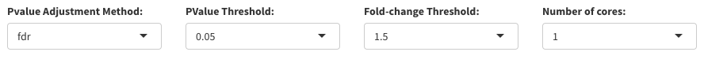

## Fold-change filtering results

The results of the filtering by fold-change will be displayed in a table with the following columns:

- **Exp:** the name of the experiment
- **Time:** the time point of the experiment
- **Feature:** the name of the gene
- **logFC:** the name of the gene
- **P.value:** the pvalue obtained from the analysis
- **adj.P.Val:** the adjusted pvalues
- **useddFilteringPVal:** the pvalue used to filter the results. If the adjustment is performed, useddFilteringPVal will be equal to adj.P.Val, otherwise will be equal to P.value

# BMD Analysis

The benchmark dose (BMD) is the dose or concentration of a substance that corresponds to a specified level of response above or below that observed in a control or background population. The specified level of response within this definition is referred to as the benchmark response (BMR), while the statistical lower confidence bound of the BMD (referred to as BMDL) and the statistical upper confidence bound on the BMD (BMDU) have been typically used by regulatory agencies to set safe levels of exposure. BMD modelling involves fitting the experimental data, in this case, the gene expression values, to a selection of mathematical models, such as linear, second- or third- degree polynomial, an exponential model, hill model, asymptotic regression model, and Michaelis-Menten model. Additionally, when multiple models can be fitted to the same gene, their average consensus model can be also produced. The best model is selected by using a goodness of fit criteria, such as the Akaike information and the goodness-of-fit p-value. Alternatively, the average consensus model can be also used. A predefined response level of interest, the BMR, is identified and the optimal model is used to predict the corresponding dose (BMD) (Abraham et al. 2012). Moreover, the European Food Safety Authority (EFSA) suggest reporting both the lower and upper 95% confidence limit on the BMD called BMDL and BMDU respectively (EFSA Scientific Committee et al. 2017).

## Model Fitting

### Linear Model

$$f(dose) = \beta_0 + \beta_1 dose$$
Where $\beta_0$ is the control response (intercept), and $\beta_1$ is the slope.

### Polynomial Model

$$f(dose) = \beta_0 + \beta_1 dose + \beta_2 dose^2 + \ldots + \beta_n
dose^n$$
Where $\beta_0$ is the control response (intercept), $\beta_1, \dots, \beta_n$ are the polynomial coefficients, and $n$ is the degree of the polynomial.

### Power Model

$$f(dose) = \beta_0 + \beta_1 \times (dose)^\delta$$
Where $\beta_0$ is the control response (intercept), $\beta_1$ is the slope, and $\delta$ is the power.

### Hill Model

$$f(dose) = \beta_0 + \frac{v \times dose^n}{K^n + dose^n}$$
Where $\beta_0$ is the control response, $v$ is the maximum response, $K$ is the dose at which half the maximum response is reached, and $n$ is the Hill coefficient.

### Exponential Model

#### Exp2:

$$f(dose) = a \times e^{\pm b \times dose}$$

#### Exp3:

$$f(dose) = a \times e^{\pm (b \times dose)^d}$$

#### Exp4:

$$f(dose) = a \times (c - (c-1) \times e^{\pm b \times dose})$$

#### Exp5:

$$f(dose) = a \times (c - (c-1) \times e^{\pm (b \times dose)^d})$$
Where $a$ is the control response (intercept), $b$ is the slope, $c$ is the asymptote term, and $d$ is the power.

### Log-Logistic Model

#### Log-Logistic 5:

$$f(dose, (b, c, d, e, f)) = c +
\frac{d-c}{(1+\exp(b(\log(dose)-\log(e))))^f}$$
If $f \neq 1$, the function is asymmetric; otherwise, it is symmetric (on a log scale).

#### Log-Logistic 4:

$$f(dose, (b, c, d, e)) = c + \frac{d-c}{1+\exp(b(\log(dose)-\log(e)))}$$
The function is symmetric about the inflection point $e$.

#### Log-Logistic 3:

$$f(dose, (b, c, e)) = c + \frac{1-c}{1+\exp(b(\log(dose)-\log(e)))}$$
The function is symmetric about the inflection point $e$.

#### Log-Logistic 2:

$$f(dose, (b, e)) = \frac{1}{1+\exp(b(\log(dose)-\log(e)))}$$
The function is symmetric about the inflection point $e$.

### Weibull Models

#### Weibull 1.2:

$$f(dose, (b, e)) = 1 - \exp(-b \cdot dose^e)$$
This model describes an asymmetric sigmoidal growth curve.

#### Weibull 1.3:

$$f(dose, (b, d, e)) = d - d \cdot \exp(-b \cdot dose^e)$$
Extends Weibull 1.2 by adding a scaling parameter $d$ that adjusts the upper asymptote.

#### Weibull 1.4:

$$f(dose, (b, c, d, e)) = c + (d - c) \cdot (1 - \exp(-b \cdot dose^e))$$
Allows both upper ($d$) and lower ($c$) asymptotes, providing greater flexibility.

#### Weibull 2.2:

$$f(dose, (b, e)) = \exp(-\exp(b \cdot (\log(dose) - e)))$$
A sigmoidal decay function where $e$ is the inflection point.

#### Weibull 2.3:

$$f(dose, (b, d, e)) = d \cdot \exp(-\exp(b \cdot (\log(dose) - e)))$$
Extends Weibull 2.2 with a scaling parameter $d$, modifying the maximum response.

#### Weibull 2.4:

$$f(dose, (b, c, d, e)) = c + (d - c) \cdot \exp(-\exp(b \cdot (\log(dose)
- e)))$$
Generalizes Weibull 2.3 by incorporating both lower ($c$) and upper ($d$) asymptotes.

### Michaelis-Menten Model

#### MM.3 Model:

$$f(dose, (c, d, e)) = c + \frac{d-c}{1+(e/dose)}$$
This model increases as a function of dose, attaining the lower limit $c$ at dose $0$ and the upper limit $d$ for infinitely large doses. The parameter $e$ corresponds to the dose yielding a response halfway between $c$ and $d$.

#### MM.2 Model:

A two-parameter version of the Michaelis-Menten model is obtained by setting $c=0$.

### Average model

BMDx implements model averaging through an AIC-based combination of models fitted to the same gene’s dose-response data. By calculating Akaike weights from the AIC values of each model, it assigns relative probabilities to the models, reflecting their support from the data. Predictions for benchmark dose (BMD), lower bounds (BMDL), and upper bounds (BMDU) are generated for each model and combined using these weights to produce averaged estimates. This approach ensures that the final predictions account for model uncertainty, integrating information from multiple models while penalizing overly complex or poorly fitting ones.

#### Model Averaging Methodology

For every gene with multiple available models, the **average model** is obtained by weighting the predictions of the models by their AIC values. This ensures that models with a better fit contribute more to the final prediction while models with poorer fits have less influence.

The following steps are followed:

1. **Fitting individual models**: Each model is fitted separately to the dose-response data.
2. **Computing AIC values**: The Akaike Information Criterion (AIC) values for each model are extracted.
3. **Calculating Akaike Weights**:
   - The difference between each model’s AIC and the minimum AIC is computed.
   - These differences are transformed into Akaike weights using the softmax function:

   $$w_i = \frac{\exp(-\frac{AIC_i - AIC_{min}}{2})}{\sum \exp(-\frac{AIC_i -
   AIC_{min}}{2})}$$

   where $w_i$ represents the weight assigned to each model.
4. **Computing Weighted Predictions**:
   - Each model’s predictions for BMD, BMDL, and BMDU are obtained.
   - The final averaged prediction is computed as:

   $$\hat{Y} = \sum w_i \cdot Y_i$$

   where $Y_i$ is the prediction from each model.

## Model comparison

Model comparison is performed by means of the Akaike Information Criterion (AIC) implemented in the R stats package as follows:

$$-2 x log-likelihood + k x
npar$$

where $npar$ represents the number of parameters in the fitted model, and $k=2$ for the usual AIC.

## Model Variance

BMDx provides multiple options for handling variance assumptions when fitting dose-response models. Users can specify whether variance should be treated as **constant**, **nonconstant**, or **model-dependent**, or they can allow the tool to infer the appropriate variance assumption based on statistical testing.

### Implementation Details

If `control_variance` is set to `"infer"`, BMDx applies the Levene test to assess variance homogeneity across groups. The test evaluates whether population variances are equal (null hypothesis). If the test result (p-value) is below the selected significance level, variance is classified as **nonconstant**; otherwise, it is considered **constant**.

For **constant variance**, the model estimates variance using the residuals from all samples. For **nonconstant variance**, only residuals from control samples (dose = 0) are used for variance estimation. If **model-based variance** is selected, a variance function is fitted to the residuals, and variance predictions are incorporated into a weighted regression model to refine the estimates dynamically.

## Model Adverse Direction

The adverse direction of the models is determined based on the sign of specific model parameters. This estimation follows different approaches depending on the model type:

- **Linear Model:** The sign of the slope coefficient is used to determine the direction of the adverse response. A positive slope indicates a **positive (+1)** adverse reaction, while a negative slope indicates a **negative (-1)** adverse reaction.
- **Power Model:** The sign of the **b** coefficient is used to assess the adverse direction. A positive **b** coefficient corresponds to a **positive (+1)** adverse reaction, whereas a negative **b** coefficient corresponds to a **negative (-1)** adverse reaction.
- **Hill Model:** The sign of the **v** coefficient is used to estimate the adverse reaction direction. A positive **v** coefficient indicates a **positive (+1)** adverse reaction, while a negative **v** coefficient indicates a **negative (-1)** adverse reaction.
- **Polynomial, Exponential, and Models from the `drc` Package:** For these models, a linear regression is performed, and the sign of the slope coefficient is used to estimate the adverse reaction direction. A positive slope results in a **positive (+1)** adverse reaction, whereas a negative slope results in a **negative (-1)** adverse reaction.

## R² Calculation

The coefficient of determination (**R²**) is used to evaluate the goodness of fit of the models. It quantifies the proportion of variance in the observed data that is explained by the fitted model. Different model types use distinct approaches to compute **R²**, as described below:

- **Models from the `drc` package**:
  The **R²** value is computed using the variance-based formula:
  $$R^2 = 1 - \frac{\text{Var}(\text{residuals})}{\text{Var}(\text{observed
  values})}$$
  where the residual variance is divided by the variance of the observed response values, providing a measure of how well the model accounts for the data variability.
- **Exponential Model**:  
  The **R²** value is computed using the `modelr::rsquare()` function, which applies a standard squared correlation approach between observed and predicted values, ensuring consistency in nonlinear regression evaluation.
- **Hill Model**:  
  The **R²** value is computed similarly to the exponential model, using `modelr::rsquare()`. This function assesses the proportion of explained variance by comparing fitted values with observed responses.
- **Linear Model**:
  For linear regression models, **R²** is derived from the standard formula used in `lm()` results:
  $$R^2 = 1 - \frac{\sum (y_{\text{obs}} - y_{\text{pred}})^2}{\sum
  (y_{\text{obs}} - \bar{y})^2}$$
  where $y_{\text{obs}}$ represents the observed response, $y_{\text{pred}}$ the predicted values, and $\bar{y}$ the mean of the observed responses. The **R²** value is extracted directly from `summary(lm())$r.squared`.
- **Polynomial Models**:  
  Similar to the linear model, polynomial models use the standard **R²** computation from `summary(lm())$r.squared`. Since polynomials are fitted using linear regression techniques, their goodness-of-fit evaluation follows the same approach.
- **Power Model**:  
  The **R²** value for power models is computed using `modelr::rsquare()`, as in the exponential and Hill models. This function provides a robust measure of the proportion of variance explained by the fitted model.

### Interpretation

An **R²** value close to 1 indicates that the model explains a high proportion of the variability in the observed data, while an **R²** value close to 0 suggests that the model does not provide a good fit. It is important to note that **R²** does not inherently account for model complexity, so it should be interpreted alongside other model selection criteria, such as AIC.

## BMR Selection and BMD estimation

The BMR can be computed by means of three different methods: standard deviation, relative and absolute. The standard deviation method for normal distributed responses it is defined as

$$\dfrac{| m(BMD) -m(0) |}{s(0)} = BMRF$$

Where $s(0)$ is the standard deviation of the controls, and $m(0)$ is the predicted value of the response at the control level. The BMRF is the multiple of the standard deviation, whose default value1.349 corresponds to a 10% of difference with respect to the controls. Thus, the BMD (benchmark doses) is the estimated dose, whose predicted value $m(BMD)$ corresponds to the desired BMRF.

## BMDL/BMDU Estimation

The **Benchmark Dose Lower Bound (BMDL)** and **Benchmark Dose Upper Bound (BMDU)** values are estimated using confidence interval methods as suggested by Gaylor et al. (1998). This approach provides an uncertainty range for the Benchmark Dose (BMD), ensuring that the estimated dose-response relationship accounts for statistical variability.

### **Methodology**

The estimation of BMDL and BMDU is based on the **confidence interval of the predicted dose-response curve**. Given a predefined confidence level (e.g., 95%), the **lower (BMDL)** and **upper (BMDU)** bounds are determined by interpolating the benchmark response (BMR) within the confidence interval of the fitted model.

1. **Computation of the Confidence Interval**
   - A confidence interval is constructed around the predicted response using the model’s standard error estimates.
   - The confidence level (e.g., 95%) defines the range within which the true dose-response relationship is expected to lie.
2. **Interpolation of BMDL and BMDU**
   - If the adverse direction of the response is **negative (-1)**, BMDL is computed as the **lower bound** of the confidence interval, while BMDU is the **upper bound**.
   - If the adverse direction is **positive (+1)**, BMDL is interpolated from the **upper bound**, while BMDU is obtained from the **lower bound**.
3. **Handling Errors and Warnings**
   - If the confidence interval estimation fails due to numerical issues or model constraints, BMDL and BMDU are assigned **NA values**, indicating that the bounds could not be determined.

### **Implementation in BMDx**

BMDL and BMDU are computed using the **`predict()`** function on a range of dose values spanning the observed data. The interpolation is performed using the **`stats::approx()`** function to estimate the benchmark dose bounds at the benchmark response (BMR) level. The estimated values are then stored as **BMDL** and **BMDU** in the model output.

This methodology is aligned with the **U.S. Environmental Protection Agency (EPA) recommendations** for benchmark dose estimation, following the framework outlined by Gaylor et al. (1998) [(link)](https://moscow.sci-hub.se/1557/eba6caff4cc96262194738e8280bdc7d/gaylor1998.pdf#view=FitH).

## Selection of Parameters for bmd modelling

The BMD analysis requires the following parameters:

- **Number of cores:** The number of cores that are used during the analysis
- **Maximum Iterations:** Is the maximum number of iterations allowed as a convergence criteria
- **Data type:** Is a string character describing the type of response. Possible values are continuous (default) and binomial
- **Deviation type:** Is a string character describing the type of deviation computed. Possible values are standard (default) and relative and absolute.
- **BMR factor:** Is the number of standard deviation at which the BMD is defined. The default value is 1.349, which corresponds to a change of 10% with respect to the controls. For further information refer to the following papers: Thomas, Russell S, Bruce C Allen, Andy Nong, Longlong Yang, Edilberto Bermudez, Harvey J Clewell, and Melvin E Andersen. 2007. “A Method to Integrate Benchmark Dose Estimates with Genomic Data to Assess the Functional Effects of Chemical Exposure.” Toxicological Sciences 98 (1): 240–48. https://doi.org/10.1093/toxsci/kfm092; Filipsson, Agneta Falk, Salomon Sand, John Nilsson, and Katarina Victorin. 2003. “The Benchmark Dose Method–Review of Available Models, and Recommendations for Application in Health Risk Assessment.” Critical Reviews in Toxicology 33 (5): 505–42. https://doi.org/10.1080/10408440390242360.
- **Confidence interval:** The statistical confidence limit applied to the BMD estimated from the models.
- **Variance type:** Is a string character describing the type of variance of the data. Possible values are constant (default), non constant, model and inferred.
- **Significance threshold for levene test:** In case of variance type equal to inferred, a levene test is used to test the assumption of constant or non constant variance. This parameter specify the threshold for the significant p-value for the test. Default value is 0.05.
- **Lack-of-fit p-value:** Threshold used to identify good fitted models. Default 0.1
- **Select models:** Predefined subselection of the available models. Possible values are custom, regulatory, degree of freedom, all. The user can use any of the available subset of models or select the models himself from the checkbox list. Regulatory models include models of interest for regulatory agencies. Degree of freedom models comprise models with a degree of freedom less than n-1, considering n is the number of doses tested. Custom allows for manual selection of desired models.

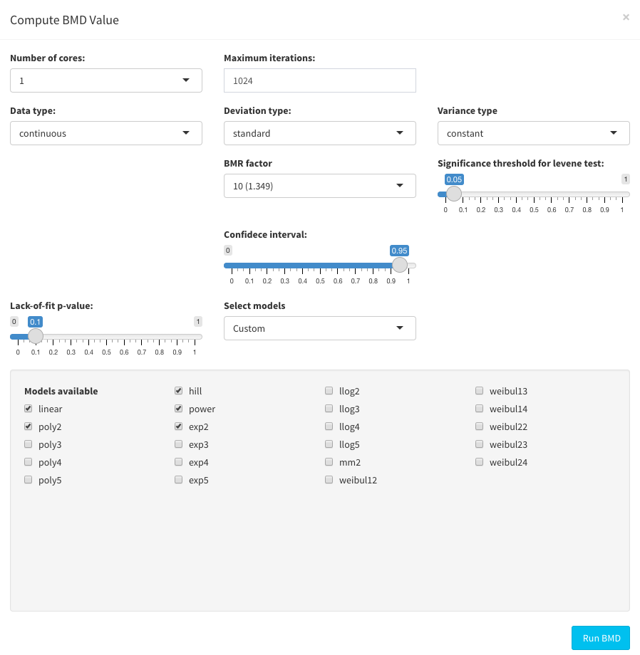

BMD parameters.

# BMD Results

The results of the BMD analysis will be reported in a tabular format with the following column names:

- **Experiment:** The name of the experiment
- **time_point:** The time point of the experiment
- **Feature:** The name of the gene
- **Model:** The model fitted
- **BMR:** The expression of the gene at the response level
- **BMDL:** The estimated BMDL
- **BMD:** The estimated BMD
- **BMDU:** The estimated BMDU
- **AC50:** The estimated AC50
- **Adverse_direction:** Indicate if the model is increasing along the doses (+1) or decreasing (-1)
- **AIC:** The Akaike information criterion computed for the model
- **Lack_of_fit:** The lack of fit p-value
- **Log_likelihood:** The log-likelihood of the data given the model
- **R2:** The R2 square associated with the model
- **Residual_variance:** The variance of the residual represent differences between observed values and the values predicted by the model. It represents how much of the variability of response is not explained by the model.

The table reports all the models that can be estimated for every gene.

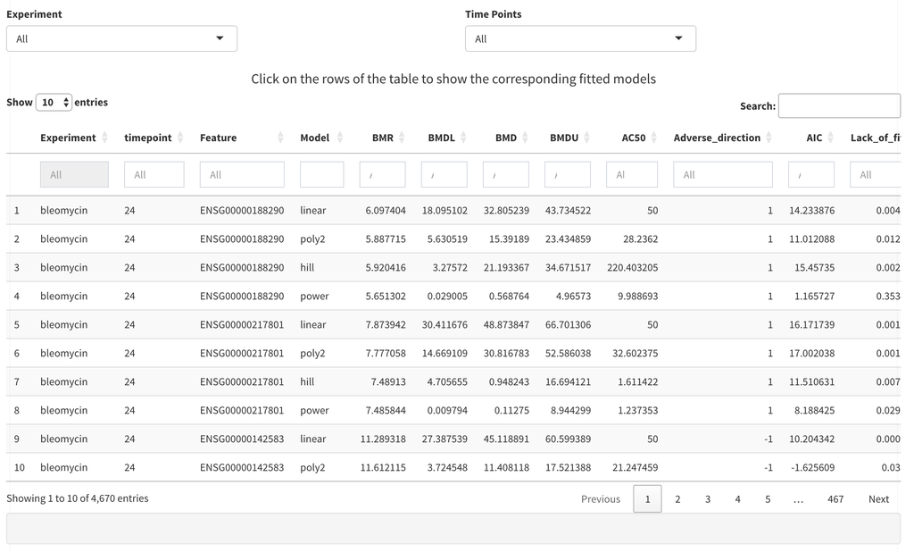

BMD results

## Filtering BMD Results

The user can discard the model fitted and displayed in the BMD analysis result table by means of the following criteria:

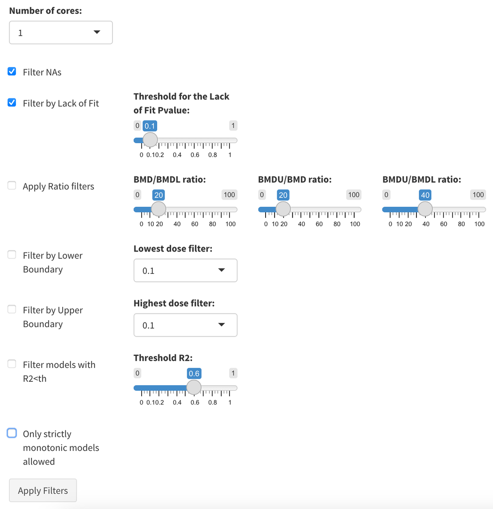

Filtering of BMD results.

## Selection of the optimal model

The selection of the final optimal model for every gene can be selected as the one with the lowest AIC value, or as the average consensus model. The consensus model should be computed only merging the models that pass the filtering criteria.

## Visual investigation of the models

When clicking on a row of the BMD result table, the model fitted to the response data of the corresponding gene is visualized along with the corresponding effective doses. Furthermore the model formula with the estimated parameters are also visualised.

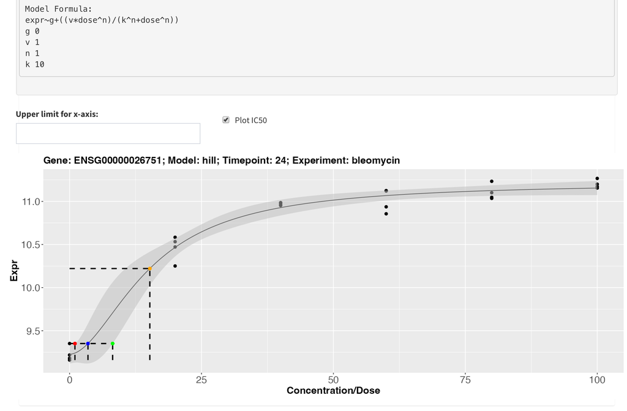

BMD model fitting of a specific gene.

#Compare different experiments

Once the models have been fitted their distribution across different experiments and different time-points can be explored by different visualizations.

### BMD histograms

The density distribution of the BMD values can be investigated by means of histograms. The user can select the relevant variable of interest and different grouping variables. Filtering can be also performed to plot only a subset of the results.

The following parameters are required:

- **Color by:** how the bmd values are going to be colored. This should be a factor variable whose levels will be used to fill the legend
- **Group by X:** the bmd values can be grouped by a factor variable
- **Group by Y (optional):** the bmd values can be grouped by another optional factor variable to perform a grid plot
- **Filter by Column:** Can be used to investigate the bmd distribution of specific variable of interest. Default is None which means that no filtering is applied. However, if one of the column names is selected the **Filter by Column Values** window is populated by the possible column values. When one of those is selected, only the bmd corresponding to the genes characterized by those values are investigated (e.g. only the bmd produced by a specific model).

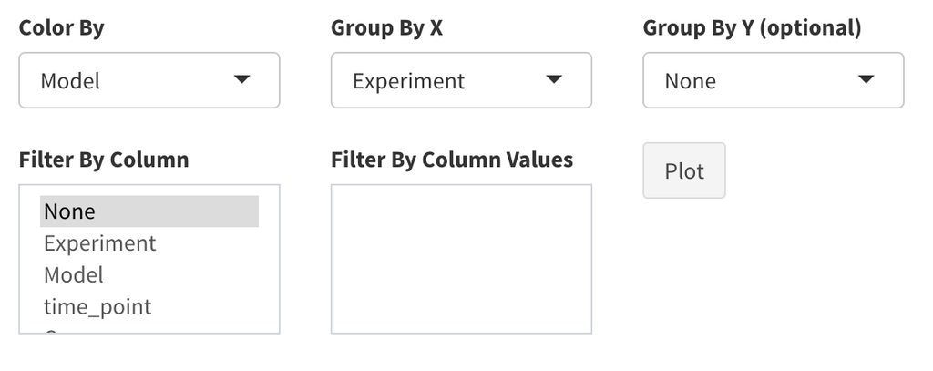

Parameters for plotting BMD histogram.

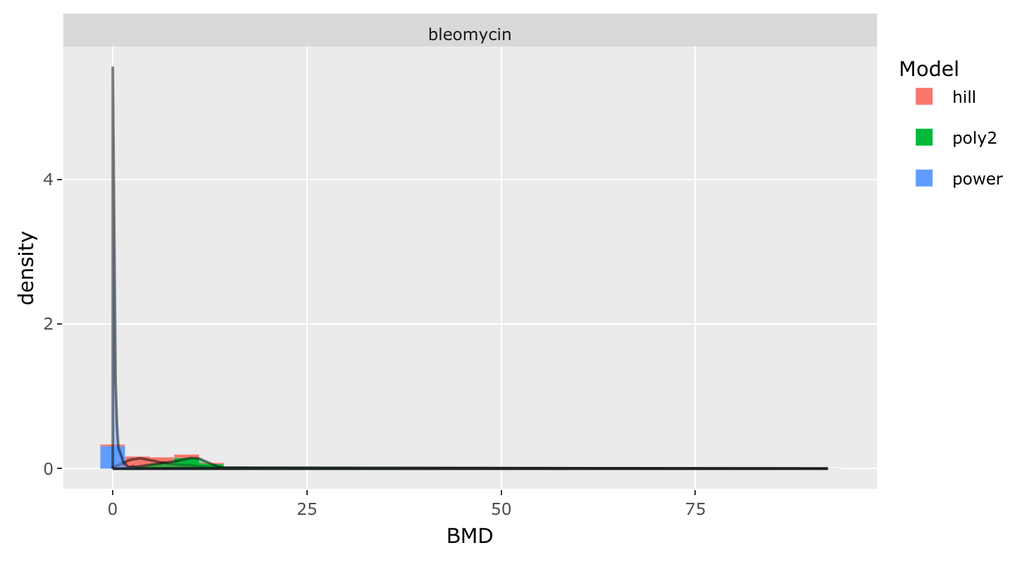

BMD density

### Fitting statistics

The distribution of the lack-of-fit p-values, AIC, and $R^2$ can be investigated by means of histograms. The user can select the relevant variable of interest and different grouping variables. Filtering can be also performed to plot only a subset of the results.

The following parameters are required:

- **Color by:** how the bmd values are going to be colored. This should be a factor variable whose levels will be used to fill the legend
- **Group by X:** the bmd values can be grouped by a factor variable
- **Group by Y (optional):** the bmd values can be grouped by another optional factor variable to perform a grid plot
- **Filter by Column:** Can be used to investigate the bmd distribution of specific variable of interest. Default is None which means that no filtering is applied. However, if one of the column names is selected the **Filter by Column Values** window is populated by the possible column values. When one of those is selected, only the bmd corresponding to the genes characterized by those values are investigated (e.g. only the bmd produced by a specific model).

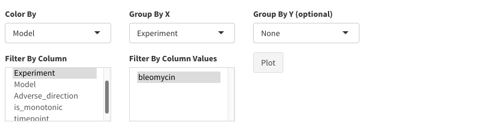

Parameters for plotting the distribution of the lack-of-fit p-values

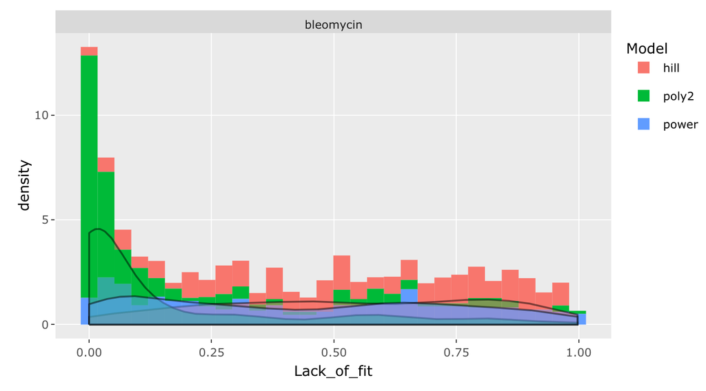

Lack-of-fit.

### BMD/BMDL

The relationship between the BMD/BMDL values can be investigated by means of scatterplots. The user can select the relevant variable of interest and different grouping variables. Filtering can be also performed to plot only a subset of the results. The following parameters are required:

- **Color by:** how the bmd values are going to be colored. This should be a factor variable whose levels will be used to fill the legend
- **Group by X:** the bmd values can be grouped by a factor variable
- **Group by Y (optional):** the bmd values can be grouped by another optional factor variable to perform a grid plot
- **Filter by Column:** Can be used to investigate the bmd distribution of specific variable of interest. Default is None which means that no filtering is applied. However, if one of the column names is selected the **Filter by Column Values** window is populated by the possible column values. When one of those is selected, only the bmd corresponding to the genes characterized by those values are investigated (e.g. only the bmd produced by a specific model).

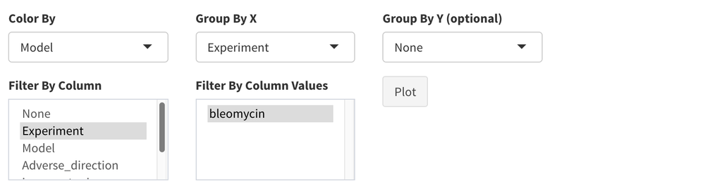

Parameters for plotting the relationship between BMD/BMDL.

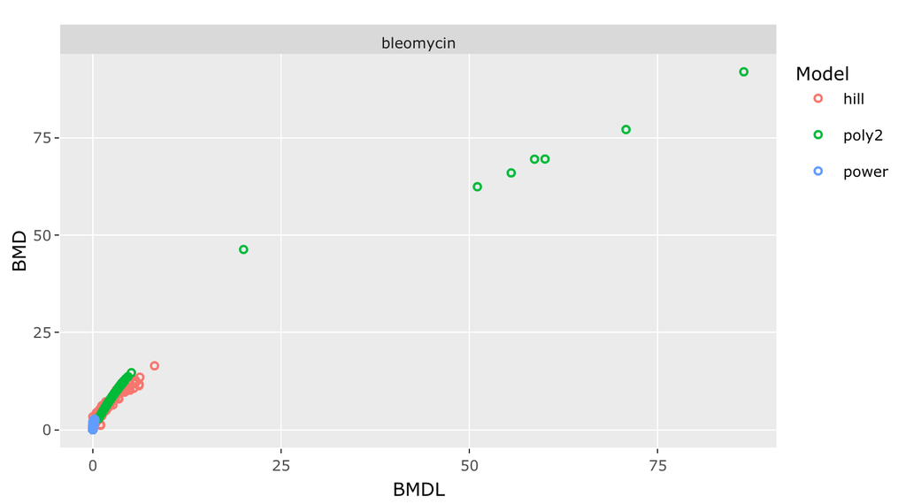

Relationship between the BMD/BMDL values

### Fitted models

The proportion of fitted models can be investigated by means of pie charts. The user can select different grouping variables. Filtering can be also performed to plot only a subset of the results. In this plot the variable of interest is fixed to the models and cannot be changed by the user.

The following parameters are required:

- **Group by X:** the bmd values can be grouped by a factor variable
- **Group by Y (optional):** the bmd values can be grouped by another optional factor variable to perform a grid plot
- **Filter by Column:** Can be used to investigate the bmd distribution of specific variable of interest. Default is None which means that no filtering is applied. However, if one of the column names is selected the **Filter by Column Values** window is populated by the possible column values. When one of those is selected, only the bmd corresponding to the genes characterized by those values are investigated (e.g. only the bmd produced by a specific model).

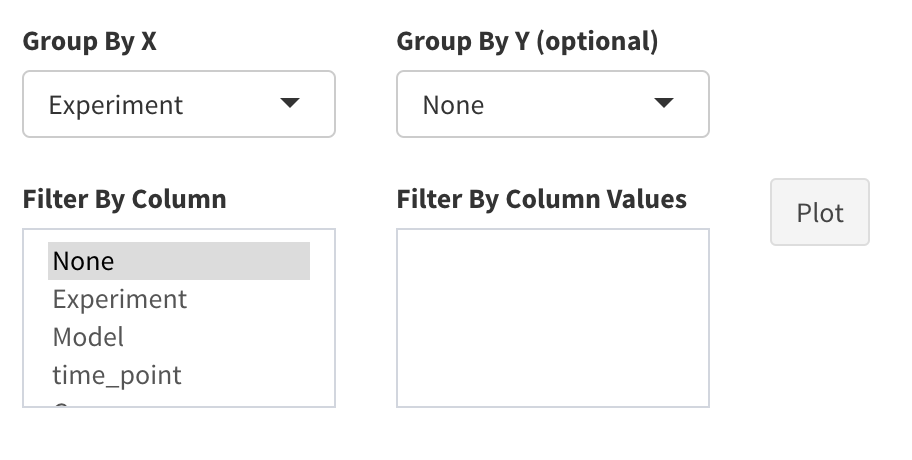

Parameters to compute the proportion of fitted models.

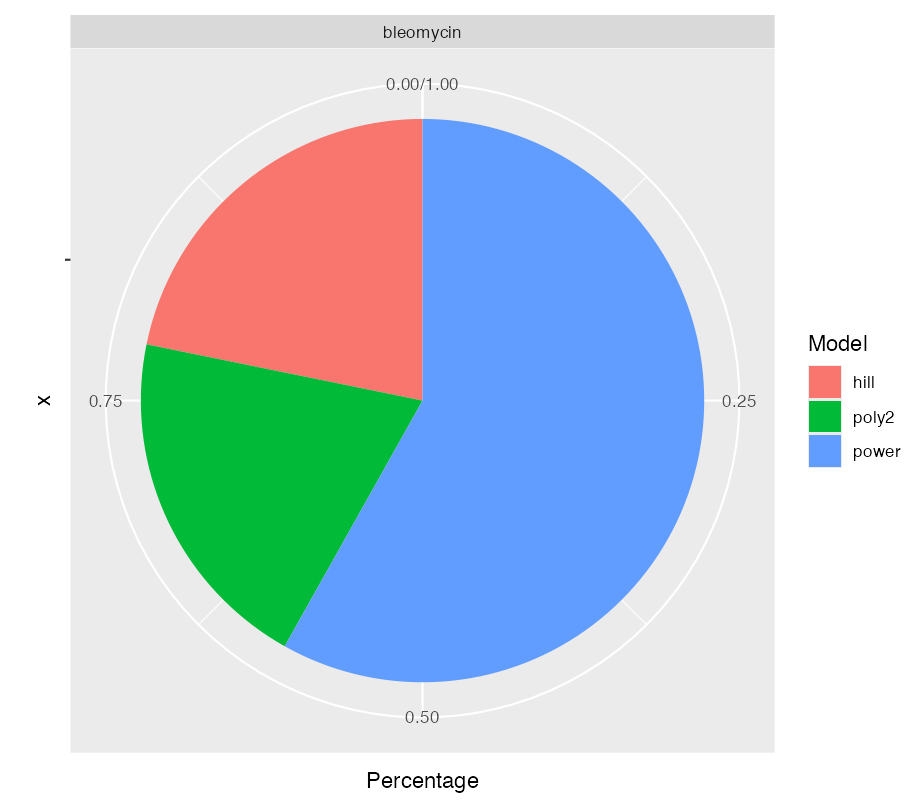

Proportion of fitted models to compute BMD.

### Number of dose-dependent genes

The proportion of dose-dependent genes by time points can be investigated by means of barplots. The user can select the grouping variable. Filtering can be also performed to plot only a subset of the results. In this plot the variable of interest is fixed to the time point and cannot be changed by the user.

The following parameters are required:

- **Group by X:** the bmd values can be grouped by a factor variable
- **Filter by Column:** Can be used to investigate the bmd distribution of specific variable of interest. Default is None which means that no filtering is applied. However, if one of the column names is selected the **Filter by Column Values** window is populated by the possible column values. When one of those is selected, only the bmd corresponding to the genes characterized by those values are investigated (e.g. only the bmd produced by a specific model).

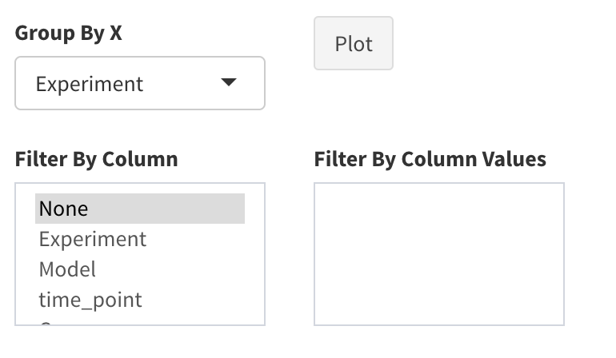

Parameters for plotting dose-dependent genes

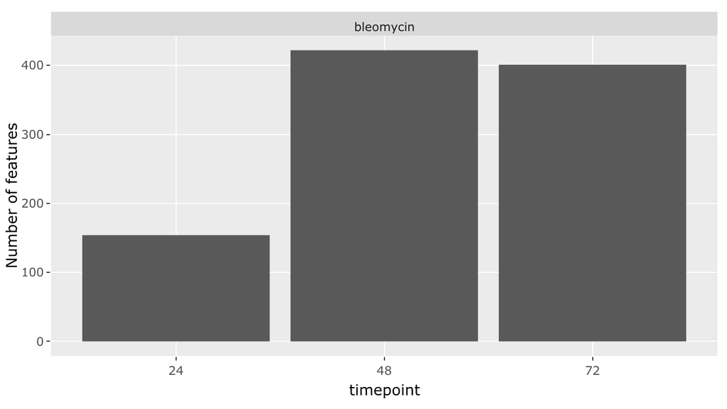

Proportion of dose-dependent genes by time points

### ECDF

The distribution of the bmd values at the whole transcriptome level can be investigated by means of the ECDF plot. This plot is showing the percentage of genes (y-axis) with a bmd lower than a certain value (x-axis). The user can select the relevant variable of interest and different grouping variables. Filtering can be also performed to plot only a subset of the results. The following parameters are required:

- **Relevant variable:** how the bmd values are going to be colored. This should be a factor variable whose levels will be used to fill the legend
- **Group by X:** the bmd values can be grouped by a factor variable
- **Numeric grouping variable:**: If true the variable is considered numerical and ordered accordingly
- **Other variables (optional):** the bmd values can be grouped by another optional factor variable to perform a grid plot
- **Filter by Column:** Can be used to investigate the bmd distribution of specific variable of interest. Default is None which means that no filtering is applied. However, if one of the column names is selected the **Filter by Column Values** window is populated by the possible column values. When one of those is selected, only the bmd corresponding to the genes characterized by those values are investigated (e.g. only the bmd produced by a specific model).
- **Scale bmd:** If selected, the bmd of different experiments (that might be in different ranges) are scaled in the range [0-1] to make them comparable.

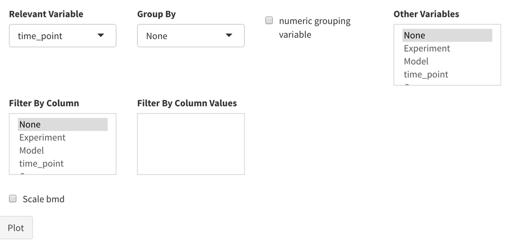

Parameters for plotting ECDF.

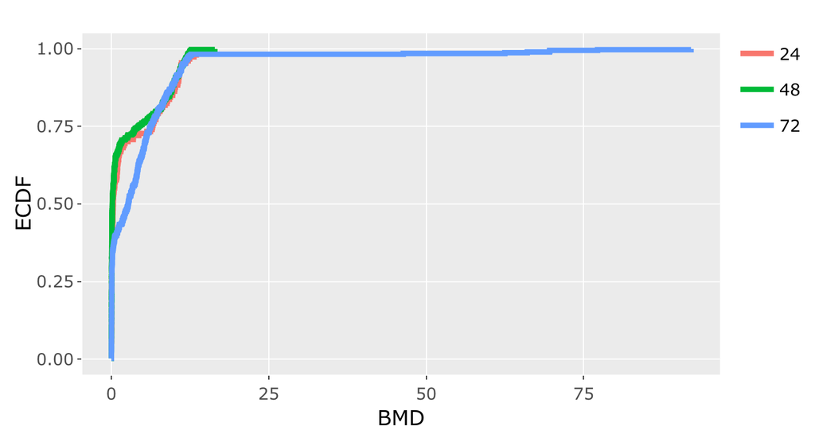

Distribution of the bmd values at the whole transcriptome level.

### Upset Plot

The number of genes shared by the different experiments can be investigated by means of an upset plot. The user can select the relevant variable of interest and different grouping variables. Filtering can be also performed to plot only a subset of the results. The following parameters are required:

- **Relevant variable:** how the bmd values are going to be colored. This should be a factor variable whose levels will be used to fill the legend
- **Group by X:** the bmd values can be grouped by a factor variable
- **Numeric grouping variable:**: If true the variable is considered numerical and ordered accordingly
- **Other variables (optional):** the bmd values can be grouped by another optional factor variable to perform a grid plot
- **Filter by Column:** Can be used to investigate the bmd distribution of specific variable of interest. Default is None which means that no filtering is applied. However, if one of the column names is selected the **Filter by Column Values** window is populated by the possible column values. When one of those is selected, only the bmd corresponding to the genes characterized by those values are investigated (e.g. only the bmd produced by a specific model).
- **Maximum intersection:** Maximum number of intersection to show
- **GroupBy:** UpsetPlot parameter
- **OrderBy:** UpsetPlot parameter

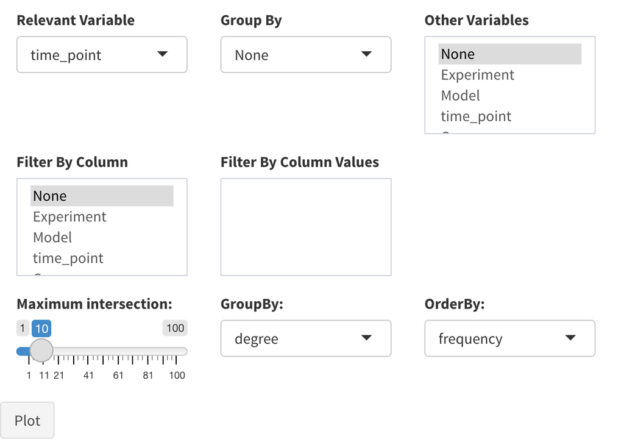

Parameters for plotting upset plot.

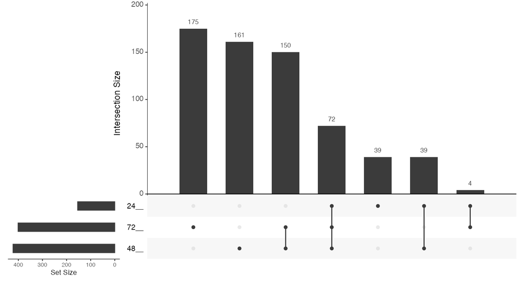

# Gene frequency analysis

The aim of this analysis is to identify genes who are more often dose-dependent across different experiments or time points. The genes are ranked according to their occurrence frequency across the different experiments. Genes with a frequency below a certain threshold can be removed from the analysis. The tool compute the frequencies of the genes and plots them using a horizontal barplot, where genes are ranked based on their frequency. A GSEA is performed by means of the gprofiler package on the ranked list of genes.

The following parameters are required:

- **Main grouping variable:** Use to group the samples into categories. Gene frequency will be computed accordingly.
- **Second grouping variable:** Use to group the samples into categories. Gene frequency will be computed accordingly.
- **Threshold:**: Used to filter out genes with low frequency. E.g. if 50% is selected, the genes with frequency below this number will not be included in further analysis
- **Organism:** to be specified for the GSEA analysis. Available organisms are human, mouse and rat.
- **Correction method:** Is the correction method applied to the GSEA p-values
- **Choose split:** If a split is performed this parameter can be used to show the GSEA results of the specific subset of samples

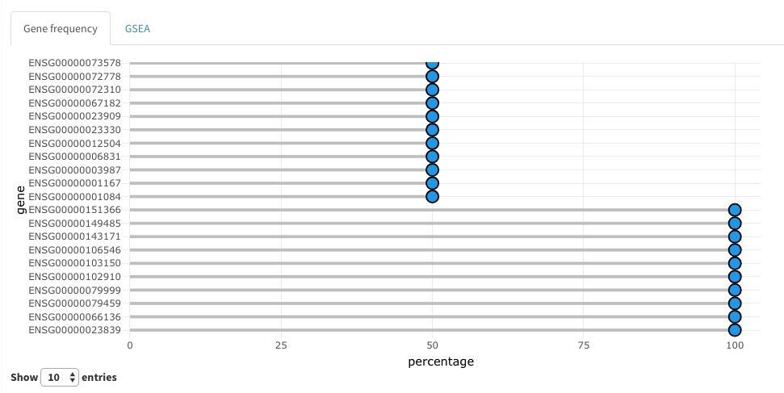

Lollipop gene frequency

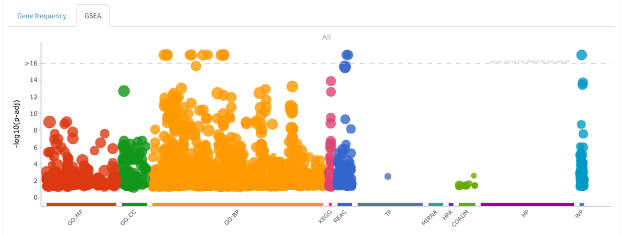

gsea

# FunMappOne enrichment analysis

FunMappOne is a user friendly tool for the comparison of functional enrichment analysis af multiple experiments. The tool is publicly available [at](https://github.com/Greco-Lab/FunMappOne). Please refer to the FunMappOne paper for more [details](https://bmcbioinformatics.biomedcentral.com/articles/10.1186/s12859-019-2639-2).

The FunMappOne tools is embedded into the BMDx as a module for the functional characterization of the dose-dependent genes.

### Heatmap visualization

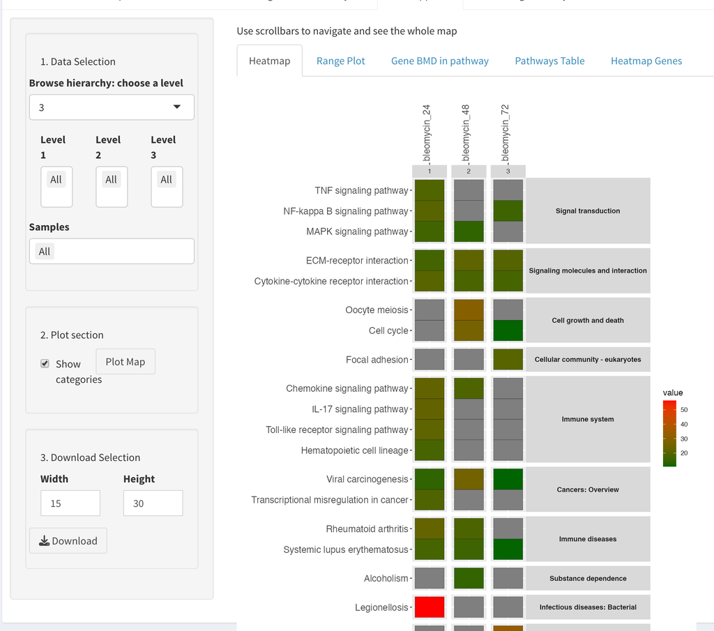

Heatmap of enrichment results from FunMappOne

### Range plot

A range plot can be visualised to show the span of values of the BMDL, BMD and BMDU of the different enriched pathways. The following parameters are required:

- **Groupd by X:** the pathways can be grouped by a factor variable
- **Numeric grouping variable:**: If true the variable is considered numerical and ordered accordingly
- **Other variables (optional):** the pathways can be grouped by another optional factor variable to perform a grid plot
- **Filter by Column:** Can be used to investigate the bmd distribution of specific variable of interest. Default is None which means that no filtering is applied. However, if one of the column names is selected the **Filter by Column Values** window is populated by the possible column values. When one of those is selected, only the bmd corresponding to the genes characterized by those values are investigated (e.g. only the bmd produced by a specific model).

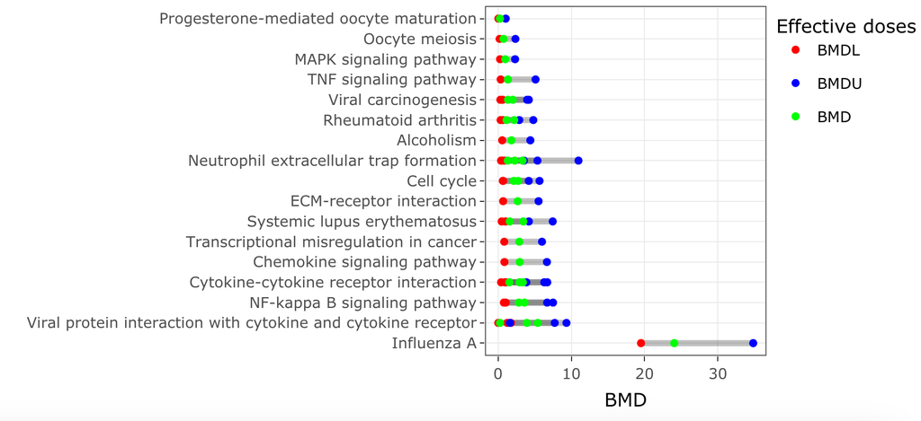

Range plot BMD, BMDL, and BMDU values

### Gene BMD in pathway

Gene BMD in a Pathway tab shows all pathways with their enrichment p-values. Selecting a row of the table plots a graph under the table with all the genes in the pathway, their BMD values as well as the lower and upper confidence bound BMD. Note! Deselect the row before selecting the next row to only include the genes in the desired pathway.

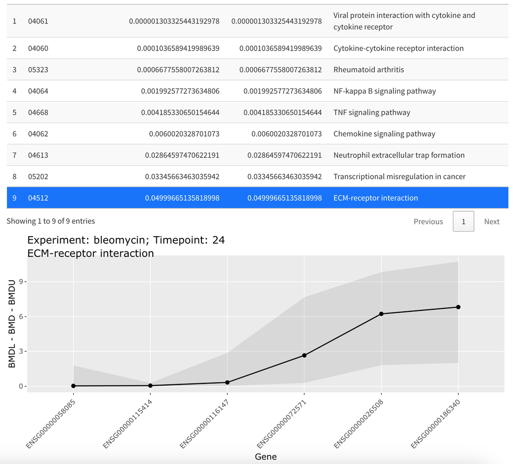

BMD values of genes belonging to a selected pathway